# Simulation layers in bSims

Peter Solymos

Introductory stats books begin with the coin flip to introduce the binomial distribution. In R we can easily simulate an outcome from such a random variable $Y \sim Binomial(1, p)$ doing something like this:

```r
p <- 0.5

Y <- rbinom(1, size = 1, prob = p)
```

But a coin flip in reality is a lot more complicated: we might consider the initial force, the height of the toss, the spin, and the weight of the coin.

Bird behavior combined with the observation process presents a more complicated system, that is often treated as a mixture of a count distribution and a detection/nondetection process, e.g.:

```r
D <- 2 # individuals / unit area
A <- 1 # area
p <- 0.8 # probability of availability given presence
q <- 0.5 # probability of detection given availability

N <- rpois(1, lambda = A * D)
Y <- rbinom(1, size = N, prob = p * q)
```

This looks not too complicated, corresponding to the true abundance being a random variables $N \sim Poisson(DA)$, while the observed count being $Y \sim Binomial(N, pq)$. This is the exact simulation that we need when we want to make sure that an *estimator* can estimate the *model* parameters (`lambda` and `prob` here). But such probabilistic simulations are not very useful when we are interested how well the *model* captures important aspects of *reality*.

Going back to the Poisson–Binomial example, `N` would be a result of all the factors influencing bird abundance, such as geographical location, season, habitat suitability, number of conspecifics, competitors, or predators. `Y` however would largely depend on how the birds behave depending on timing, or how an observer might detect or miss the different individuals, or count the same individual twice, etc.

Therefore the package has layers, that by default are *conditionally independent* of each other. This design decision is meant to facilitate the comparison of certain settings while keeping all the underlying realizations identical, thus helping to pinpoint effects without the extra variability introduced by all the other effects.

The conditionally independent *layers* of a **bSims** realization are the following, with the corresponding function:

1. landscape (`bsims_init`),
2. population (`bsims_populate`),
3. behavior with movement and vocalization events (`bsims_animate`),
4. the physical side of the observation process (`bsims_detect`), and
5. the human aspect of the observation process (`bsims_transcribe`).

See this example as a sneak peek that we’ll explain in the following subsections:

```r
library(bSims)

phi <- 0.5                 # singing rate
tau <- 1:3                 # detection distances by strata
tbr <- c(3, 5, 10)         # time intervals
rbr <- c(0.5, 1, 1.5)      # count radii

l <- bsims_init(extent=10, # landscape
  road=0.25, edge=0.5)
p <- bsims_populate(l,     # population
  density=c(1, 1, 0))
e <- bsims_animate(p,      # events
  vocal_rate=phi,
  move_rate=1, movement=0.2)
d <- bsims_detect(e,       # detections
  tau=tau)
x <- bsims_transcribe(d,   # transcription
  tint=tbr, rint=rbr)

get_table(x) # removal table
```

```
#>          0-3min 3-5min 5-10min
#> 0-50m         0      0       0
#> 50-100m       0      1       0
#> 100-150m      3      0       1
```

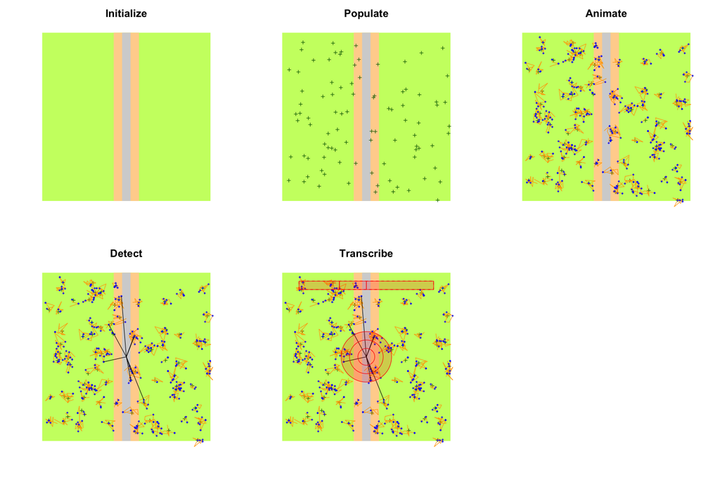

```r
op <- par(mfrow=c(2,3), cex.main=2)
plot(l, main="Initialize")
plot(p, main="Populate")
plot(e, main="Animate")
plot(d, main="Detect")
plot(x, main="Transcribe")
par(op)
```

## Landscape

The `bsims_ini` function sets up the geometry of a local landscape. The `extent` of the landscape determines the edge lengths of a square shaped area. With no argument values passed, the function assumes a homogeneous *habitat* (H) in a 10 units x 10 units landscape, 1 unit is 100 meters. Having units this way allows easier conversion to ha as area unit that is often used in the North American bird literature. As a result, our landscape has an area of 1 km$^2$.

The `road` argument defines the half-width of the road that is placed in a vertical position. The `edge` argument defines the width of the edge stratum on both sides of the road. Habitat (H), edge (E), and road (R) defines the 3 strata that we refer to by their initials (H for no stratification, HER for all 3 strata present).

The origin of the Cartesian coordinate system inside the landscape is centered at the middle of the square. The `offset` argument allows the road and edge strata to be shifted to the left (negative values) or to the right (positive values) of the horizontal axis. This makes it possible to create landscapes with only two strata. The `bsims_init` function returns a landscape object (with class ‘bsims_landscape’).

```r
(l1 <- bsims_init(extent = 10, road = 0, edge = 0, offset = 0))
```

```
#> bSims landscape
#>   1 km x 1 km
#>   stratification: H
```

```r
(l2 <- bsims_init(extent = 10, road = 1, edge = 0, offset = 0))
```

```
#> bSims landscape
#>   1 km x 1 km
#>   stratification: HR
```

```r
(l3 <- bsims_init(extent = 10, road = 0.5, edge = 1, offset = 2))
```

```
#> bSims landscape
#>   1 km x 1 km
#>   stratification: HER
```

```r
(l4 <- bsims_init(extent = 10, road = 0, edge = 5, offset = 5))
```

```
#> bSims landscape
#>   1 km x 1 km
#>   stratification: HE
```

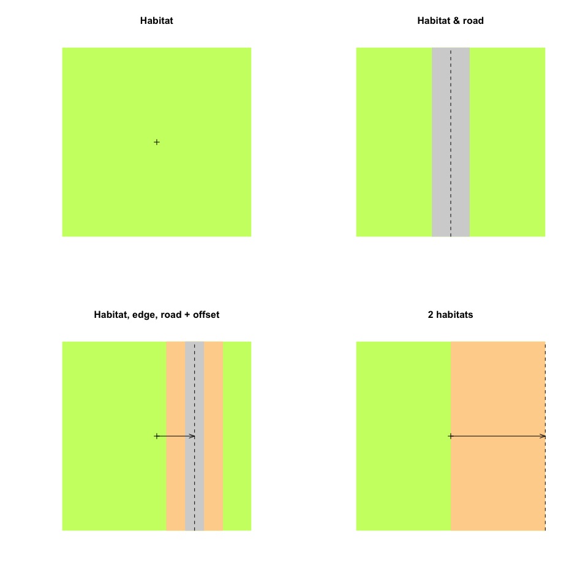

```r
op <- par(mfrow = c(2, 2))
plot(l1, main = "Habitat")
points(0, 0, pch=3)
plot(l2, main = "Habitat & road")
lines(c(0, 0), c(-5, 5), lty=2)
plot(l3, main = "Habitat, edge, road + offset")
arrows(0, 0, 2, 0, 0.1, 20)
lines(c(2, 2), c(-5, 5), lty=2)
points(0, 0, pch=3)
plot(l4, main = "2 habitats")
arrows(0, 0, 5, 0, 0.1, 20)
lines(c(5, 5), c(-5, 5), lty=2)
points(0, 0, pch=3)
```

```r
par(op)
```

## Population

The `bsims_populate` function *populates* the landscape we created by the `bsims_init` function, which is the first argument we have to pass to `bsims_populate`. The function returns a population object (with class ‘bsims_population’). The most important argument that controls how many individuals will inhabit our landscape is `density` that defines the expected value of individuals per unit area (1 ha). By default, `density = 1` ($D=1$) and we have 100 ha in the landscape ($A=100$) which translates into 100 individuals on average ($E[N]=\lambda=AD$). The actual number of individuals in the landscape might deviate from this expectation, because $N$ is a random variable ($N \sim f(\lambda)$). The `abund_fun` argument controls this relationship between the expected ($\lambda$) and realized abundance ($N$). The default is a Poisson distribution:

```r
bsims_populate(l1)
```

```
#> bSims population
#>   1 km x 1 km
#>   stratification: H
#>   total abundance: 97
```

Changing `abund_fun` can be useful to make abundance constant or allow under or overdispersion, e.g.:

```r
summary(rpois(100, 100)) # Poisson variation
```

```
#>    Min. 1st Qu.  Median    Mean 3rd Qu.    Max.
#>    72.0    94.0   100.0   100.7   107.0   130.0
```

```r
summary(MASS::rnegbin(100, 100, 0.8)) # NegBin variation
```

```
#>    Min. 1st Qu.  Median    Mean 3rd Qu.    Max.
#>    0.00   15.75   69.00  106.59  147.25  563.00
```

```r
negbin <- function(lambda, ...) MASS::rnegbin(1, lambda, ...)
bsims_populate(l1, abund_fun = negbin, theta = 0.8)
```

```
#> bSims population
#>   1 km x 1 km
#>   stratification: H
#>   total abundance: 109
## constant abundance
```

```r
bsims_populate(l1, abund_fun = function(lambda, ...) lambda)
```

```
#> bSims population
#>   1 km x 1 km
#>   stratification: H
#>   total abundance: 100
```

Once we determine how many individuals will populate the landscape, we have control over the spatial arrangement of the nest location for each individual. The default is a homogeneous Poisson point process (complete spatial randomness). Deviations from this can be controlled by the `xy_fun`. This function takes distance as its only argument and returns a numeric value between 0 and 1. A function `function(d) reurn(1)` would be equivalent with the Poisson process, meaning that every new random location is accepted with probability 1 irrespective of the distance between the new location and the previously generated point locations in the landscape. When this function varies with distance, it leads to a non-homogeneous point process via this accept-reject algorithm. The other arguments (`margin`, `maxit`, `fail`) are passed to the underlying `accepreject` function to remove edge effects and handle high rejection rates.

In the next example, we fix the abundance to be constant (i.e. not a random variable, $N=\lambda$) and different spatial point processes:

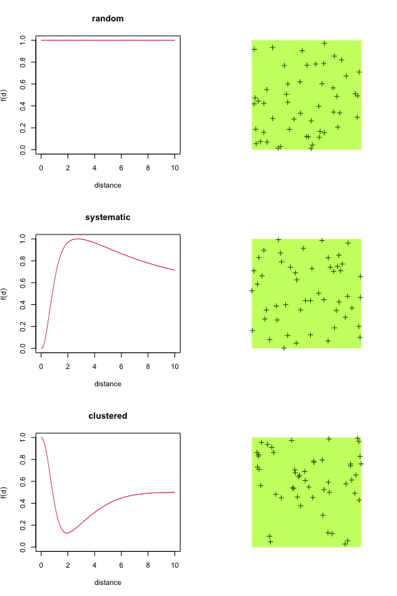

```r
D <- 0.5
f_abund <- function(lambda, ...) lambda

## systematic
f_syst <- function(d)
  (1-exp(-d^2/1^2) + dlnorm(d, 2)/dlnorm(exp(2-1),2)) / 2
## clustered
f_clust <- function(d)
  exp(-d^2/1^2) + 0.5*(1-exp(-d^2/4^2))

p1 <- bsims_populate(l1, density = D, abund_fun = f_abund)
p2 <- bsims_populate(l1, density = D, abund_fun = f_abund, xy_fun = f_syst)
p3 <- bsims_populate(l1, density = D, abund_fun = f_abund, xy_fun = f_clust)

distance <- seq(0,10,0.01)
op <- par(mfrow = c(3, 2))
plot(distance, rep(1, length(distance)), type="l", ylim = c(0, 1),
  main = "random", ylab=expression(f(d)), col=2)
plot(p1)

plot(distance, f_syst(distance), type="l", ylim = c(0, 1),
  main = "systematic", ylab=expression(f(d)), col=2)
plot(p2)

plot(distance, f_clust(distance), type="l", ylim = c(0, 1),
  main = "clustered", ylab=expression(f(d)), col=2)
plot(p3)
```

```r
par(op)
```

The `get_nests` function extracts the nest locations. `get_abundance` and `get_density` gives the total abundance ($N$) and density ($D=N/A$, where $A$ is `extent^2`) in the landscape, respectively.

If the landscape is stratified, that has no effect on density unless we specify different values through the `density` argument as a vector of length 3 referring to the HER strata:

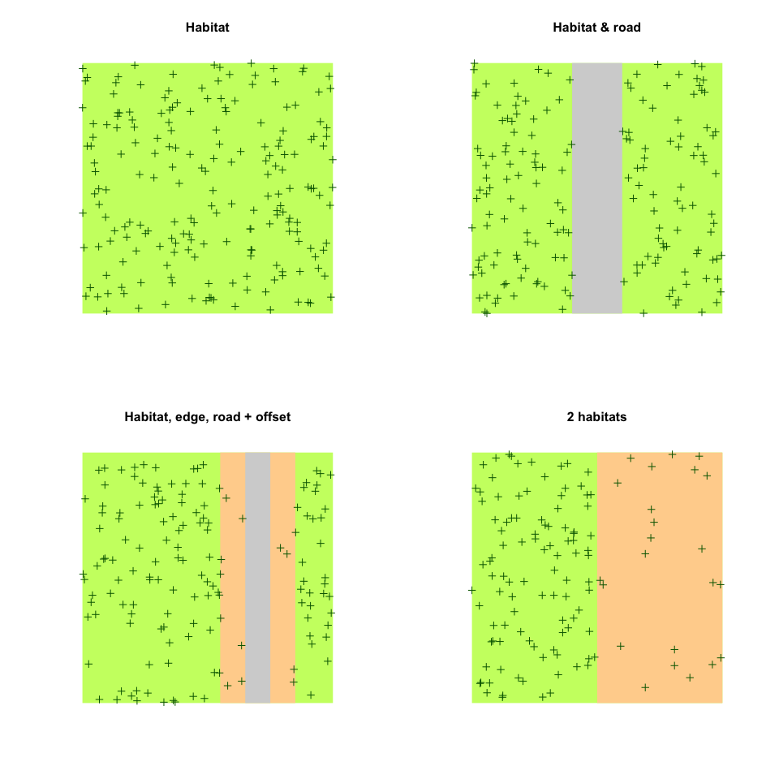

```r
D <- c(H = 2, E = 0.5, R = 0)

op <- par(mfrow = c(2, 2))
plot(bsims_populate(l1, density = D), main = "Habitat")
plot(bsims_populate(l2, density = D), main = "Habitat & road")
plot(bsims_populate(l3, density = D), main = "Habitat, edge, road + offset")
plot(bsims_populate(l4, density = D), main = "2 habitats")
```

```r
par(op)
```

## Behavior

The `bsims_animate` function *animates* the population created by the `bsims_populate` function. `bsims_animate` returns an events object (with class ‘bsims_events’). The most important arguments are governing the `duration` of the simulation in minutes, the vocalization (`vocal_rate`), and the movement (`move_rate`) rates as average number of events per minute.

We can describe these behavioral events using survival modeling terminology. Event time ($T$) is a continuous random variable. In the simplest case, its probability density function is the Exponential distribution: $f(t)=\phi e^{-t\phi}$. The corresponding cumulative distribution function is: $F(t)=\int_{0}^{t} f(t)dt=1-e^{-t\phi}=p_t$, giving the probability that the event has occurred by duration $t$. The parameter $\phi$ is the rate of the Exponential distribution with mean $1/\phi$ and variance $1/\phi^2$.

In survival models, the complement of $F(t)$ is called the *survival function* ($S(t)=1-F(t)$, $S(0)=1$), which gives the probability that the event has not occurred by duration $t$. The *hazard function* ($\lambda(t)=f(t)/S(t)$) defines the instantaneous rate of occurrence of the event (risk, the density of events at $t$ divided by the probability of surviving). The cumulative hazard (cumulative risk) is the sum of the risks between duration 0 and $t$ ($\Lambda(t)=\int_{0}^{t} \lambda(t)dt$).

The simplest survival distribution assumes constant risk over time ($\lambda(t)=\phi$), which corresponds to the Exponential distribution. The Exponential distribution also happens to describe the lengths of the inter-event times in a homogeneous Poisson process (events are independent, it is a ‘memory-less’ process).

`bsims_animate` uses independent Exponential distributions with rates `vocal_rate` and `move_rate` to simulate vocalization and movement events, respectively. The `get_events` function extracts the events as a data frame with columns describing the location (`x`, `y`) and time (`t`) of the events (`v` is 1 for vocalizations and 0 otherwise) for each individual (`i` gives the individual identifier that links individuals to the nest locations)

```r
l <- bsims_init()
p <- bsims_populate(l, density = 0.5)
e1 <- bsims_animate(p, vocal_rate = 1)

head(get_events(e1))
```

```
#>           x          y           t v   a  i
#> 1 -2.508184  2.6764407 0.004043933 1 155  4
#> 2  3.876671  4.4885743 0.022987967 1 314 34
#> 3 -1.840156  0.3421961 0.031965954 1 108  1
#> 4 -1.416870 -2.0850311 0.044264103 1 276 19
#> 5  4.112376 -3.7872979 0.105670752 1 223 53
#> 6  2.000265  2.9710303 0.125082360 1 216 43
```

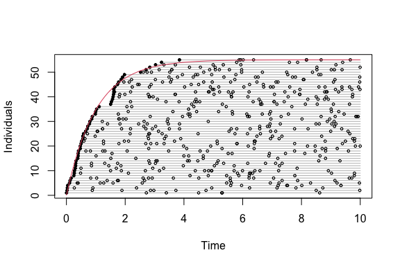

```r
plot(get_events(e1))
curve((1-exp(-1*x)) * get_abundance(e1), col=2, add=TRUE)
```

There are no movement related events when `move_rate = 0`, the individuals are always located at the nest, i.e. there is no within territory movement. If we increase the movement rate, we also have to increase the value of `movement`, that is the standard deviation of bivariate Normal kernels centered around each nest location. This kernel is used to simulate new locations for the movement events.

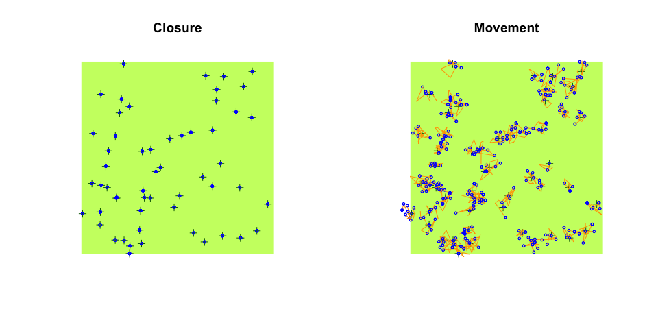

```r
e2 <- bsims_animate(p, move_rate = 1, movement = 0.25)

op <- par(mfrow = c(1, 2))
plot(e1, main = "Closure")
plot(e2, main = "Movement")
```

```r
par(op)
```

Individuals in the landscape might have different vocalization rates depending on, e.g., breeding status. Such heterogeneity can be added to the simulations as a finite mixture: `vocal_rate` and `move_rate` can be supplied as a vector, each element giving the rate for the groups. The `mixture` argument is then used to specify the mixture proportions.

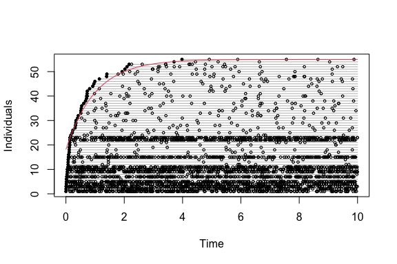

```r
e3 <- bsims_animate(p,
  vocal_rate = c(25, 1), mixture = c(0.33, 0.67))

plot(get_events(e3))
curve((1-0.67*exp(-1*x)) * get_abundance(e3), col=2, add=TRUE)
```

Vocal and movement rates (and corresponding kernel standard deviations) can be defined four different ways:

- a single number: constant behavior patterns, no groups,
- a vector of length `length(mixture)`: behavior based finite mixture groups,
- a vector of length 3 with `mixture = 1`: mixtures correspond to HER strata,
- or a matrix of dimension 3 $\times$ `length(mixture)`: HER strata $\times$ number of behavior based groups.

Strata based groups are tracked by column `s`, behavior based groups are tracked as the column `g` in the output of `get_nests`.

Here is how different territory sizes can be achieved in a two-habitat landscape:

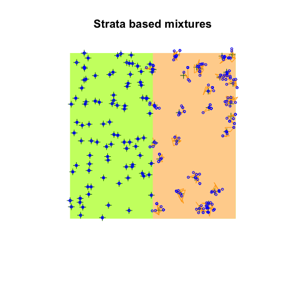

```r
plot(bsims_animate(bsims_populate(l4, density = D),
  move_rate = c(0.5, 1, 1), movement = c(0, 0.2, 0.2),
  mixture = 1), main="Strata based mixtures")
```

Stratum related behavior groups depend on the nest location. Sometimes it makes sense to restrict movement even further, i.e. individuals do not land in certain strata (but can cross a stratum if `movement` is large enough). For example, we can restrict movement into the road stratum (this requires density to be 0 in that stratum):

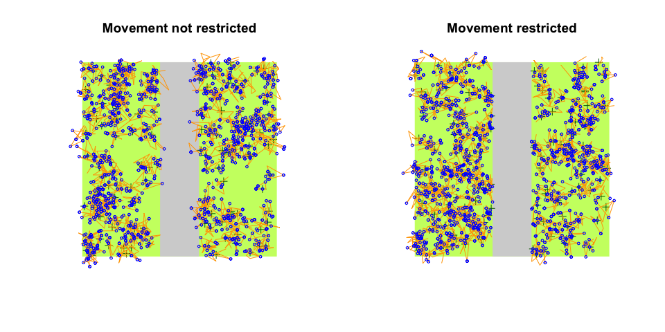

```r
op <- par(mfrow = c(1, 2))
plot(bsims_animate(bsims_populate(l2, density = D),
  move_rate = 1, movement = 0.3,
  avoid = "none"), main="Movement not restricted")
plot(bsims_animate(bsims_populate(l2, density = D),
  move_rate = 1, movement = 0.3,
  avoid = "R"), main="Movement restricted")
```

```r
par(op)
```

Another way to restrict the movement of individuals is to prevent the overlap based on a Voronoi tessellation around the nest locations. Note: we are using the update method here to update the `allow_overlap` argument of the previous call, and the plot method from the **deldir** package used for tessellation.

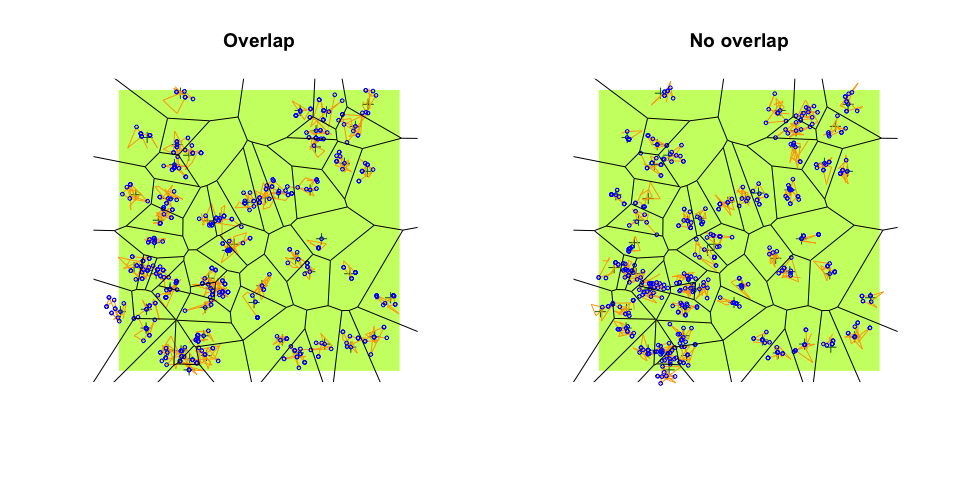

```r
e4 <- update(e2, allow_overlap=FALSE)

op <- par(mfrow = c(1, 2))
plot(e2, main = "Overlap")
plot(e2$tess, add=TRUE, wlines="tess",
  showpoints=FALSE, cmpnt_lty=1)
plot(e4, main = "No overlap")
plot(e4$tess, add=TRUE, wlines="tess",
  showpoints=FALSE, cmpnt_lty=1)
```

```r
par(op)
```

We haven’t mentioned the `initial_location` argument yet. This allows to override this whole layer and make all individuals fully available for the other layers applied on top. I.e. it is possible to study the observation process without any behavioral interference when `initial_location = TRUE`.

## Detection

The `bsims_detect` function *detects* the events created by the `bsims_animate` function. `bsims_detect` returns a detections object (with class ‘bsims_detections’). The argument `xy` defines the location of the observer in the landscape. By default, it is in the middle, but can be moved anywhere within the bounds of the landscape.

`tau` is the parameter of the distance function `dist_fun`. The distance function ($g(d)$) describes the monotonic relationship of how the probability of detecting an individual decreases with distance ($d$). Detection probability at 0 distance is 1.

The most commonly used distance function is the Half-Normal. This is a one-parameter function ($g(d) = e^{-(d/\tau)^2}$) where probability initially remain high, reflecting an increased chance of detecting individuals closer to the observer ($\tau^2$ is variance of the unfolded Normal distribution, $\tau^2/2$ is the variance of the Half-Normal distribution). Run `run_app("distfunH")` to launch a **shiny** app to explore different distance functions, like Hazard rate.

The distance function must take distance `d` as its 1st argument and the parameter `tau` is its second argument (other arguments can be passed as well). E.g. the default is `function(d, tau) exp(-(d/tau)^2)`, or the Hazard rate function can be written as `function(d, tau, b=2) 1-exp(-(d/tau)^-b)`.

Individuals are detected via auditory and visual cues that are related to vocalization or movement events, respectively. The `event_type` argument determines what kinds of events can be detected, vocalization, movement, or both. Detection here refers to the Bernoulli process with probability $g(d)$ given the actual linear distance between the individual at that time and the observer. The `get_detections` function extracts the events that are detected, the column `d` contains the distances (in 100 m units).

```r
(d1 <- bsims_detect(e2, tau = 2))
```

```
#> bSims detections
#>   1 km x 1 km
#>   stratification: H
#>   total abundance: 55
#>   duration: 10 min
#>   detected: 17 heard
```

```r
head(get_detections(d1))
```

```
#>             x         y          t v   a        d  f  i  j
#> 6    1.799464 -1.470341 0.04064681 1 157 2.323784 NA 40 40
#> 75  -1.291339 -2.351083 0.47631453 1 197 2.682377 NA 19 19
#> 84   0.247181  1.468105 0.54997742 1 263 1.488768 NA 36 36
#> 93   0.247181  1.468105 0.62059309 1 302 1.488768 NA 36 36
#> 96   1.027734  1.267268 0.65891299 1 272 1.631627 NA 38 38
#> 120  1.620303 -1.547313 0.89806207 1 152 2.240437 NA 40 40
```

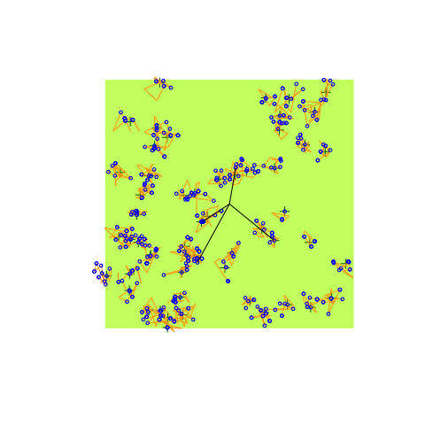

```r
plot(d1)
```

The `tau` argument can be a vector of length 3, referring to detection distances in the HER strata. When the landscape is stratified, and detection distances are different among the strata the `bsims_detect` function uses a segmented attenuation model along the linear distance between the bird and the observer. The `run_app("distfunHER")` **shiny** explores the segmented attenuation.

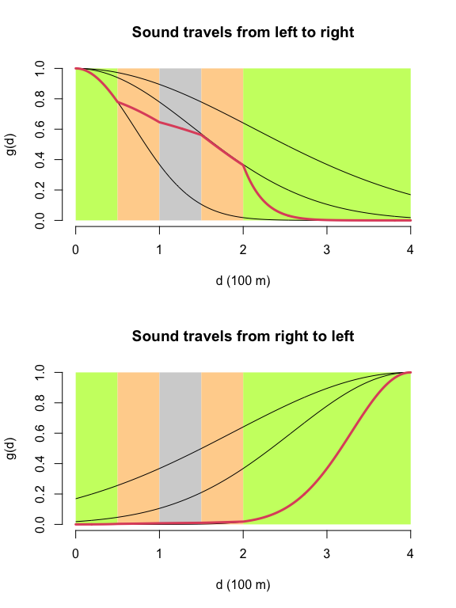

```r
tau <- c(1, 2, 3, 2, 1)
d <- seq(0, 4, 0.01)
dist_fun <- function(d, tau) exp(-(d/tau)^2) # half normal
#dist_fun <- function(d, tau) exp(-d/tau) # exponential
#dist_fun <- function(d, tau) 1-exp(-(d/tau)^-2) # hazard rate

b <- c(0.5, 1, 1.5, 2) #  boundaries

op <- par(mfrow=c(2, 1))
plot(d, dist_fun2(d, tau[1], dist_fun), type="n",
  ylab="g(d)", xlab="d (100 m)", axes=FALSE,
  main="Sound travels from left to right")
axis(1)
axis(2)
for (i in seq_len(length(b)+1)) {
  x1 <- c(0, b, 4)[i]
  x2 <- c(0, b, 4)[i+1]
  polygon(c(0, b, 4)[c(i, i, i+1, i+1)], c(0, 1, 1, 0),
    border=NA,
    col=c("darkolivegreen1", "burlywood1", "lightgrey",
    "burlywood1", "darkolivegreen1")[i])
}
lines(d, dist_fun2(d, tau[1], dist_fun))
lines(d, dist_fun2(d, tau[2], dist_fun))
lines(d, dist_fun2(d, tau[3], dist_fun))
lines(d, dist_fun2(d, tau, dist_fun, b), col=2, lwd=3)

plot(rev(d), dist_fun2(d, tau[1], dist_fun), type="n",
  ylab="g(d)", xlab="d (100 m)", axes=FALSE,
  main="Sound travels from right to left")
axis(1)
axis(2)
for (i in seq_len(length(b)+1)) {
  x1 <- c(0, b, 4)[i]
  x2 <- c(0, b, 4)[i+1]
  polygon(c(0, b, 4)[c(i, i, i+1, i+1)], c(0, 1, 1, 0),
    border=NA,
    col=c("darkolivegreen1", "burlywood1", "lightgrey",
    "burlywood1", "darkolivegreen1")[i])
}
lines(rev(d), dist_fun2(d, tau[1], dist_fun))
lines(rev(d), dist_fun2(d, tau[2], dist_fun))
lines(rev(d), dist_fun2(d, tau[3], dist_fun))
lines(rev(d), dist_fun2(d, tau, dist_fun, rev(4-b)), col=2, lwd=3)
```

```r
par(op)
```

```r
e5 <- bsims_animate(
  bsims_populate(
    bsims_init(road = 0.2, edge = 0.4), density = D),
  move_rate = 1, movement = 0.2)
(d2 <- bsims_detect(e5, tau = c(1, 2, 3), event_type = "both"))
```

```
#> bSims detections
#>   1 km x 1 km
#>   stratification: HER
#>   total abundance: 197
#>   duration: 10 min
#>   detected: 42 seen/heard
```

```r
head(get_detections(d2))
```

```
#>             x          y          t v   a         d  f   i   j
#> 9   0.2206125 -0.8845162 0.01969176 1 355 0.9116133 NA  98  98
#> 41  1.7587605  0.5350553 0.08639339 1  27 1.8383478 NA 148 148
#> 44 -0.7095295 -1.0353687 0.09058664 0  NA 1.2551575 NA  87  87
#> 55  1.2376295  0.6682096 0.11614220 0  NA 1.4064959 NA 167 167
#> 60  1.3517422  0.2430154 0.12588330 0  NA 1.3734131 NA 110 110
#> 90  1.8414770  1.1021884 0.19197317 0  NA 2.1461260 NA 114 114
```

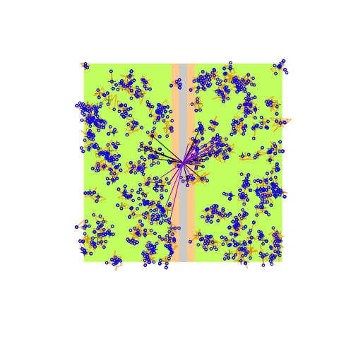

```r
plot(d2)
```

If you notice in the plot here, the detections (lines connecting the observer and the location of the events being detected) are 2 different colors. That’s because we allowed both vocalization and movement event types to be detected via the `event_type = "both"` argument. Vocalization and movement related detections might have different detection function characteristics. A flyover might be seen from larger distances, but it can also depend on body size and coloration relative to the background. For this reason, the `tau` argument can also be a vector of length 2 to provide parameters for vocalization (1st value) and movement (2nd value) related events.

Let’s use the `e2` object (no landscape stratification) and see how many individuals are hear (not seen), seen (not heard), and heard & seen:

```r
(d3 <- bsims_detect(e2, tau = c(1.5, 3), event_type = "both"))
```

```
#> bSims detections
#>   1 km x 1 km
#>   stratification: H
#>   total abundance: 55
#>   duration: 10 min
#>   detected: 43 seen/heard
```

```r
dtab <- get_detections(d3)
tmp <- with(dtab, table(i, v))
c("heard"=sum(tmp[,"0"] == 0 & tmp[,"1"] > 0),
  "seen"=sum(tmp[,"0"] > 0 & tmp[,"1"] == 0),
  "heard & seen"=sum(tmp[,"0"] > 0 & tmp[,"1"] > 0))
```

```
#>        heard         seen heard & seen
#>            0           28           15
```

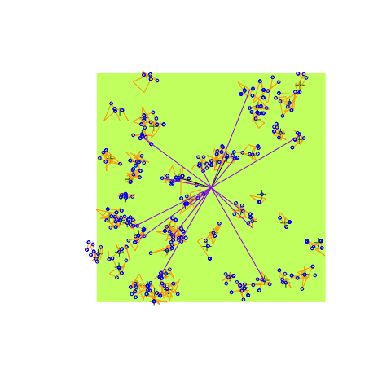

```r
plot(d3)
```

`tau` given as a $3 \times 2$ matrix combines strata (rows) and vocalization/movement (columns) related parameters, thus allowing the distance function to differ among the three strata and distinguish the event types.

The `sensitivity` argument modifies `tau` (`tau * sensitivity`), it can be specified for movement or vocal events.This is a more didactic way of introducing observer or sensor related variability into the detection process. It is still the physical process that is being affected and not the perception.

## Transcription

The last layer of simulation is the `bsims_transcribe` function that *transcribes* the detections created by the `bsims_detect` function. `bsims_transcribe` returns a detections object (with class ‘bsims_transcript’). This layer refers to the process of the observer assigning detected individuals to time and distance categories. The `tint` argument is a vector containing the endpoints of the time intervals within the total duration in minutes. `rint` defines the distance bands in 100 m units, the maximum can be infinite referring to an unlimited distance count.

The `error` argument refers to distance estimation error. This does not impact the actual distance between the bird and the observer, but it can lead to misclassification of the distance interval where the individual is assigned. The argument is the log scale standard deviation for lognormally distributed random variable representing this error.

The `condition` argument defines which events will be transcribed: `"event1"` refers to the 1st event (detected or not), `"det1"` refers to the 1st detection, `"alldet"` means all detections (possibly counting the same individual multiple times). The `event_type` argument can be redefined here, too.

`perception` creates individual identifiers as perceived by the observer. The argument defines the perceived number of individuals relative to the actual number of individuals. It can be a non-negative number (<1 values lead to under counting, >1 values lead to over counting), or `NULL` (observer correctly identifies all individuals). The algorithm uses the event based locations in a hierarchical clustering. The dendrogram is cut at a height corresponding to specified `perception` level and group membership is used as individual identifier.

The `bsims_transcribe` eventually prepares a ‘removal’ table that counts the new individuals in each time/distance interval. This table is used in removal and distance sampling. The ‘visits’ table counts individuals by time and distance interval, but counting restarts in every time interval (i.e. not just the new individuals are counted). The plot method overlays the distance bands and a representation of the time intervals.

```r
x <- bsims_transcribe(d1,
  tint = c(2, 4, 6, 8, 10),
  rint = c(0.5, 1, 1.5, Inf))
x
```

```
#> bSims transcript
#>   1 km x 1 km
#>   stratification: H
#>   total abundance: 55
#>   duration: 10 min
#>   detected: 17 heard
#>   1st event detected by breaks:
#>     [0, 2, 4, 6, 8, 10 min]
#>     [0, 50, 100, 150, Inf m]
```

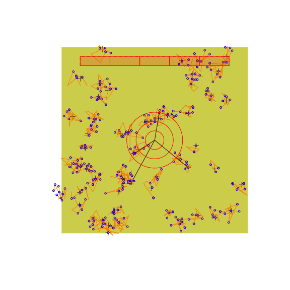

```r
plot(x)
```

```r
get_table(x, "removal")
```

```
#>          0-2min 2-4min 4-6min 6-8min 8-10min
#> 0-50m         0      0      0      0       0
#> 50-100m       0      0      0      0       0
#> 100-150m      1      1      0      0       0
#> 150+m         2      0      0      0       0
```

```r
get_table(x, "visits")
```

```
#>          0-2min 2-4min 4-6min 6-8min 8-10min
#> 0-50m         0      0      0      0       1
#> 50-100m       0      1      2      0       1
#> 100-150m      1      2      0      4       2
#> 150+m         2      4      4      3       2
```

# Statistical validity of the simulations

We can test the validity of the simulations when all of the assumptions are met (that is the default) in the homogeneous habitat case. We set singing rate (`phi`), detection distance (`tau`), and density (`Den`) for the simulations. Density is in this case unrealistically high, because we are not using replication only a single landscape. This will help with the estimation.

```r
phi <- 0.5 # singing rate
tau <- 2   # detection distance
Den <- 10  # density

set.seed(1)
l <- bsims_init()
a <- bsims_populate(l, density=Den)
b <- bsims_animate(a, vocal_rate=phi)
o <- bsims_detect(b, tau=tau)

tint <- c(1, 2, 3, 4, 5)
rint <- c(0.5, 1, 1.5, 2) # truncated at 200 m
(x <- bsims_transcribe(o, tint=tint, rint=rint))
```

```
#> bSims transcript
#>   1 km x 1 km
#>   stratification: H
#>   total abundance: 1014
#>   duration: 10 min
#>   detected: 289 heard
#>   1st event detected by breaks:
#>     [0, 1, 2, 3, 4, 5 min]
#>     [0, 50, 100, 150, 200 m]
```

```r
(y <- get_table(x, "removal")) # binned new individuals
```

```
#>          0-1min 1-2min 2-3min 3-4min 4-5min
#> 0-50m         1      4      1      1      1
#> 50-100m      10      5      3      0      1
#> 100-150m      9      5      4      2      0
#> 150-200m     12      5      4      1      1
```

```r
colSums(y)
```

```
#> 0-1min 1-2min 2-3min 3-4min 4-5min
#>     32     19     12      4      3
```

```r
rowSums(y)
```

```
#>    0-50m  50-100m 100-150m 150-200m
#>        8       19       20       23
```

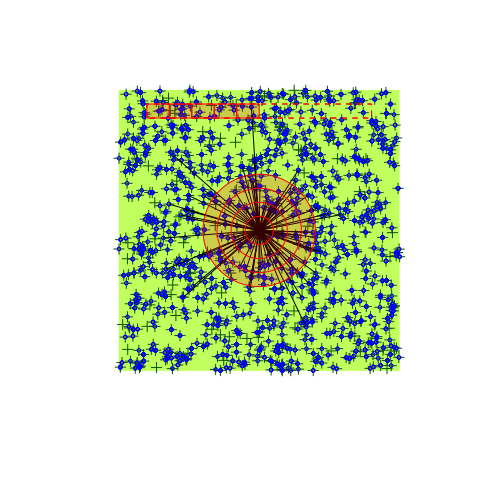

```r
plot(x)
```

We use the **detect** package to fit removal model and distance sampling model to the simulated output. This is handily implemented in the `estimate` method for the transcription objects. First, we estimate singing rate, effective detection distance, and density based on truncated distance counts:

```r
library(detect)
```

```
#> detect 0.4-6      2023-03-08
```

```r
cbind(true = c(phi=phi, tau=tau, D=Den),
  estimate = estimate(x))
```

```
#>     true  estimate
#> phi  0.5 0.5979187
#> tau  2.0 1.8996806
#> D   10.0 9.7047484
```

Next, we estimate singing rate, effective detection distance, and density based on unlimited distance counts:

```r
rint <- c(0.5, 1, 1.5, 2, Inf) # unlimited

(x <- bsims_transcribe(o, tint=tint, rint=rint))
```

```
#> bSims transcript
#>   1 km x 1 km
#>   stratification: H
#>   total abundance: 1014
#>   duration: 10 min
#>   detected: 289 heard
#>   1st event detected by breaks:
#>     [0, 1, 2, 3, 4, 5 min]
#>     [0, 50, 100, 150, 200, Inf m]
```

```r
(y <- get_table(x, "removal")) # binned new individuals
```

```
#>          0-1min 1-2min 2-3min 3-4min 4-5min
#> 0-50m         1      4      1      1      1
#> 50-100m      10      5      3      0      1
#> 100-150m      9      5      4      2      0
#> 150-200m     12      5      4      1      1
#> 200+m        15      9      6      1      3
```

```r
colSums(y)
```

```
#> 0-1min 1-2min 2-3min 3-4min 4-5min
#>     47     28     18      5      6
```

```r
rowSums(y)
```

```
#>    0-50m  50-100m 100-150m 150-200m    200+m
#>        8       19       20       23       34
```

```r
cbind(true = c(phi=phi, tau=tau, D=Den),
  estimate = estimate(x))
```

```
#>     true  estimate
#> phi  0.5 0.5731308
#> tau  2.0 1.8922130
#> D   10.0 9.8040797
```

Read more in the paper:

Solymos, P. 2023. Agent-based simulations improve abundance estimation. *Biologia Futura* 74, 377–392 [DOI 10.1007/s42977-023-00183-2](https://doi.org/10.1007/s42977-023-00183-2).